# Example: Predict Churn

박장시 jangsea.park@gmail.com

2015-06-15

고객의 접속 세션 데이터를 이용해서, 유저의 이탈 가능성을 평가하는 방법을 정리한다.

## 분석 목적

모든 개별 유저에게 이탈 유무를 기록하고, 이탈 위험 비율을 계산하여 이탈 유무를 설명하는 통계적 모형을 만들어 본다. 간략하게 요약하면 아래와 같은 함수 $f$를 생각할 수 있다.

$Probability(Churn_{k}=1) = f(RiskRatio_{k}=x)$

- Churn: 이탈 유무, 0 or 1
- Risk Ratio: 이탈 위험 비율

즉, 유저의 이탈 위험 비율을 토대로 $k$라는 유저가 이탈할 가능성을 평가한다. 예를 들어, A라는 유저의 이탈 위험 비율이 2.2이라면, 위의 모형을 통해서 해당 유저의 이탈 가능성은 0.72라는 값을 얻을 수 있다.

$Probability(Churn_{A}=1) = f(RiskRatio_{A}=2.2) = 0.72$

이를 풀어서 설명하면, 자신의 평균 접속 주기보다 2.2배의 기간동안 접속이 없었던 유저 A는 이탈할 가능성이 72%라는 의미다. 이는 임의의 예시이며, 실제 데이터를 통해서 해당 모형을 간단하게 만들 수 있다.

## 데이터 소개

분석 데이터는 아래와 같다. cid는 유저 아이디를 나타내며, datetime은 로그인 시간이다.

```
##                                    cid                   datetime
## 1 1f49ec4e-57fa-4ccb-be64-c5e2c2d4ec5e 2015-01-01 01:23:07.305536
## 2 1f49ec4e-57fa-4ccb-be64-c5e2c2d4ec5e 2015-01-10 09:34:38.781229
## 3 1f49ec4e-57fa-4ccb-be64-c5e2c2d4ec5e 2015-01-10 20:59:20.989922
## 4 1f49ec4e-57fa-4ccb-be64-c5e2c2d4ec5e 2015-01-16 12:28:16.077558
## 5 1f49ec4e-57fa-4ccb-be64-c5e2c2d4ec5e 2015-01-17 05:06:23.048913
## 6 1f49ec4e-57fa-4ccb-be64-c5e2c2d4ec5e 2015-01-21 06:15:56.067760
```

모형을 단순화하기 위해서 유저의 세션 접속 기록은 일 단위로 변환한다. 즉, 하루에 아무리 자주 접속하더라도 해당 유저의 접속 기록은 1일 1회로 표시한다.

## 데이터 가공

로그 데이터를 파일 형태로 확보했다면, 통계 모형을 만들기 전에 분석 가능한 형태로 변형해야 한다. 분석에 적합한 데이터 형태로 바꾸기 위해서 [R](http://www.r-project.org/)의 dplyr 패키지를 사용한다. 데이터 분석에 적합한 데이터 형태에 대해서는 [tidy data](http://vita.had.co.nz/papers/tidy-data.pdf)를 참고한다.

이탈 기준은 2015-03-31 시점에 마지막 접속 경과일이 8일을 초과하는 경우로 설정하였다.

```r
login <- tbl_df(login)
login$datetime <- as.POSIXct(login$datetime,
                             format = '%Y-%m-%d %H:%M:%S',
                             tz = 'UTC')
interval_logs <-
    login %>%
    group_by(cid) %>%
    mutate(next_datetime = lead(datetime),
           interval_days = as.integer(difftime(next_datetime,
                                               datetime,
                                               unit = 'days'))) %>%
    filter(interval_days > 0 & !is.na(interval_days)) %>%
    mutate(interval_number = row_number(datetime),
           last_lapse = as.integer(difftime(as.POSIXct('2015-03-31 23:59:59',
                                                       format = '%Y-%m-%d %H:%M:%S',
                                                       tz = 'UTC'),
                                            max(next_datetime),
                                            unit = 'days')),
           churn = as.integer(last_lapse > 8))
```

위와 같은 과정을 거쳐 개별 유저의 접속 주기를 계산하였다. 이 결과를 살펴보면 아래와 같은 데이터로 변환된 것을 알 수 있다.

| cid | datetime | next_datetime | interval_days | interval_number | last_lapse | churn |
| --- | --- | --- | --- | --- | --- | --- |
| 1f49ec4e-57fa-4ccb-be64-c5e2c2d4ec5e | 2015-01-01 01:23:07 | 2015-01-10 18:34:38 | 9 | 1 | 4 | 0 |
| 1f49ec4e-57fa-4ccb-be64-c5e2c2d4ec5e | 2015-01-10 20:59:20 | 2015-01-16 21:28:16 | 5 | 2 | 4 | 0 |
| 1f49ec4e-57fa-4ccb-be64-c5e2c2d4ec5e | 2015-01-17 05:06:23 | 2015-01-21 15:15:56 | 4 | 3 | 4 | 0 |
| 1f49ec4e-57fa-4ccb-be64-c5e2c2d4ec5e | 2015-01-21 06:15:56 | 2015-01-24 21:39:55 | 3 | 4 | 4 | 0 |
| 1f49ec4e-57fa-4ccb-be64-c5e2c2d4ec5e | 2015-01-24 12:39:55 | 2015-01-26 01:19:17 | 1 | 5 | 4 | 0 |
| 1f49ec4e-57fa-4ccb-be64-c5e2c2d4ec5e | 2015-01-25 16:19:17 | 2015-02-03 09:39:25 | 8 | 6 | 4 | 0 |

이를 토대로 이탈 유저의 비율을 계산할 수 있다.

```r
cnt_churn <-
  interval_logs %>%
  ungroup %>%
  filter(churn == TRUE) %>%
  summarise(cnt_churn = n_distinct(cid))

as.integer(cnt_churn) / length(unique(interval_logs$cid))
```

```
## [1] 0.1546667
```

이탈 유저의 비율은 약 0.15이다.

개별 유저들의 리스크 비율은 아래와 같이 계산한다.

```r
rr_logs <-
  interval_logs %>%
  group_by(cid) %>%
  summarise(risk_ratio = max(last_lapse) / mean(interval_days),
            churn = max(churn))
```

리스크 비율 자료는 아래와 같은 모습이다.

| cid | risk_ratio | churn |
| --- | --- | --- |
| 0000c18d-988b-4055-bca2-3ba8cc08dd97 | 0.7105263 | 0 |
| 00093b5b-7945-491b-87d6-78b9e24283e6 | 0.3544304 | 0 |
| 0010e00f-7667-4194-8cd3-a4046618968c | 0.2105263 | 0 |
| 001766d8-8418-4922-9b02-26609e68279b | 0.7894737 | 0 |
| 0047b53b-156d-4a27-8170-5357375673a8 | 1.3521127 | 0 |
| 004b8db7-e799-4374-bf8d-25859cf2ddbd | 0.2597403 | 0 |

## 모형 만들기

모형의 기본 형태는 `churn ~ risk_ratio`와 같은 모습이다. 즉, 위험 비율로 이탈 여부를 설명하는 모형을 만든다. 설명하고자 하는 변수 `churn`이 이항 사건이기 때문에 여러가지 분석 방법 중에서 [로지스틱 회귀 분석](http://en.wikipedia.org/wiki/Logistic_regression)을 사용한다. 로지스틱 회귀 분석을 사용한 이탈 예측은 여러 분야에서 [매우 많은 사례](http://www.google.co.kr/search?q=churn%20prediction%20using%20logistic%20regression)를 찾아볼 수 있다. [R](http://www.r-project.org/)에서는 아래와 같이 *glm* 함수에 *family=binomial()* 을 지정하여 로지스틱 회귀 모형을 만들 수 있다.

```r
fit <- glm(churn ~ risk_ratio, data = rr_logs, family = binomial())
```

그런데, 해당 모형은 일종의 순환 논리 오류를 가지고 있다. `churn`과 `risk_ratio`는 ’마지막 접속 경과일’에 일정 부분 종속되므로, 상당한 정보를 공유한다. 따라서 해당 모형은 표면적으로 상당히 정확한 모형으로 보일 수 밖에 없다. 바꿔 말하면, 애초에 비슷한 변수 2개를 모형의 종속 변수와 설명 변수로 설정하기 때문에 모형 자체가 갖는 의미는 크지 않다. 그럼에도 불구하고 해당 모형이 유용한 것은 위험 비율이라는 공통된 척도로 유저의 이탈 가능성을 점진적으로 도출할 수 있다는 점이다.

해당 모형으로 만든 이탈 곡선은 아래와 같다. 기본 개념에서 소개한

$Probability(Churn_{A}=1) = f(RiskRatio_{A}=2.2) = 0.72$

$P(churn=1) = \frac{1}{1+exp(9.35 -4.68 \times 2.2)} = 0.72$

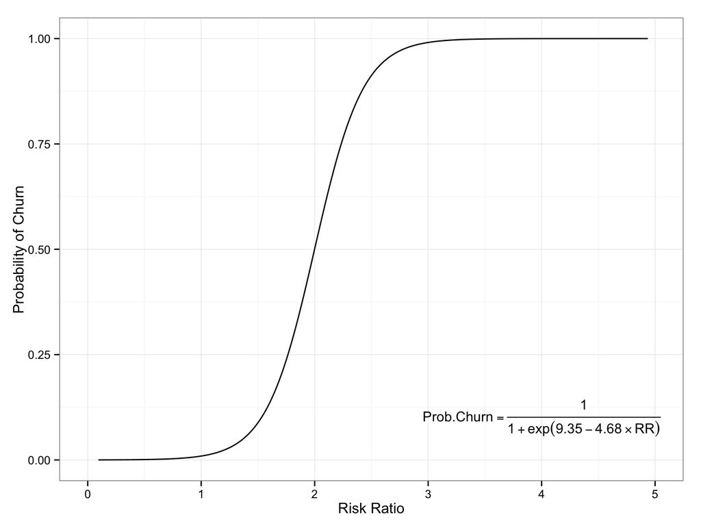

## 결론

위의 이탈 곡선을 살펴보면, 위험 비율이 1 이하일 때는 거의 이탈 가능성이 없다. 즉, 유저의 평균 접속 주기와 비슷하거나 그보다 더 짧은 기간 동안 접속이 없다면 유저의 이탈 가능성은 0이다.

그러나, 위험 비율이 2로 증가하면 유저의 이탈 가능성은 0.5로 나타난다. 이는 유저의 평균 접속 주기보다 2배 정도 긴 기간 동안 접속이 없다면 유저의 이탈 가능성은 50% 정도로 볼 수 있다는 의미다.

만약, 위험 비율이 3으로 증가하면 이탈 가능성은 거의 1이 된다. 다시 말해, 평균 접속 주기보다 3배나 긴 시간 동안 접속이 없었다면, 유저의 이탈 가능성은 100%가 된다.